# F1 Module Solutions

Shane Hauck

2022-11-15

**Formula One** The recent Netflix Docuseries Formula One: Drive to Survive has gripped audiences into becoming enthralled in the once pedestrian sport of Formula One. The growing popularity has caused for the viewers of the sport to become more interested in the specifics of the complexities of the cars. With the advancements of technology over time, it is easy to assume that cars should have gotten faster overtime. With the vast budget differential across teams, the access to better technology varies. Given a wide variety of data, lets see if we can come to a reasonable conclusion about whether cars have gotten equally faster over time.

Load tidyverse package

```r
library(tidyverse)
```

Load the necessary data for this exercise

```r
qualifying <- read_csv("data/qualifying.csv")
head(qualifying)
```

```
## # A tibble: 6 × 9
##   qualifyId raceId driverId constructorId number position q1       q2      q3
##       <dbl>  <dbl>    <dbl>         <dbl>  <dbl>    <dbl> <chr>    <chr>   <chr>
## 1         1     18        1             1     22        1 1:26.572 1:25.1… 1:26…
## 2         2     18        9             2      4        2 1:26.103 1:25.3… 1:26…
## 3         3     18        5             1     23        3 1:25.664 1:25.4… 1:27…
## 4         4     18       13             6      2        4 1:25.994 1:25.6… 1:27…
## 5         5     18        2             2      3        5 1:25.960 1:25.5… 1:27…
## 6         6     18       15             7     11        6 1:26.427 1:26.1… 1:28…
```

```r
drivers <- read_csv("data/drivers.csv")
head(drivers)
```

```
## # A tibble: 6 × 9
##   driverId driverRef  number code  forename surname    dob        nation…¹ url
##      <dbl> <chr>      <chr>  <chr> <chr>    <chr>      <date>     <chr>    <chr>
## 1        1 hamilton   "44"   HAM   Lewis    Hamilton   1985-01-07 British  http…
## 2        2 heidfeld   "\\N"  HEI   Nick     Heidfeld   1977-05-10 German   http…
## 3        3 rosberg    "6"    ROS   Nico     Rosberg    1985-06-27 German   http…
## 4        4 alonso     "14"   ALO   Fernando Alonso     1981-07-29 Spanish  http…
## 5        5 kovalainen "\\N"  KOV   Heikki   Kovalainen 1981-10-19 Finnish  http…
## 6        6 nakajima   "\\N"  NAK   Kazuki   Nakajima   1985-01-11 Japanese http…
## # … with abbreviated variable name ¹nationality
```

```r
races <- read_csv("data/races.csv")
head(races)
```

```
## # A tibble: 6 × 18
##   raceId  year round circuitId name       date       time  url   fp1_d…¹ fp1_t…²
##    <dbl> <dbl> <dbl>     <dbl> <chr>      <date>     <chr> <chr> <chr>   <chr>
## 1      1  2009     1         1 Australia… 2009-03-29 06:0… http… "\\N"   "\\N"
## 2      2  2009     2         2 Malaysian… 2009-04-05 09:0… http… "\\N"   "\\N"
## 3      3  2009     3        17 Chinese G… 2009-04-19 07:0… http… "\\N"   "\\N"
## 4      4  2009     4         3 Bahrain G… 2009-04-26 12:0… http… "\\N"   "\\N"
## 5      5  2009     5         4 Spanish G… 2009-05-10 12:0… http… "\\N"   "\\N"
## 6      6  2009     6         6 Monaco Gr… 2009-05-24 12:0… http… "\\N"   "\\N"
## # … with 8 more variables: fp2_date <chr>, fp2_time <chr>, fp3_date <chr>,
## #   fp3_time <chr>, quali_date <chr>, quali_time <chr>, sprint_date <chr>,
## #   sprint_time <chr>, and abbreviated variable names ¹fp1_date, ²fp1_time
```

```r
circuits <- read_csv("data/circuits.csv")
head(circuits)
```

```
## # A tibble: 6 × 9
##   circuitId circuitRef  name           locat…¹ country    lat    lng alt   url
##       <dbl> <chr>       <chr>          <chr>   <chr>    <dbl>  <dbl> <chr> <chr>
## 1         1 albert_park Albert Park G… Melbou… Austra… -37.8  145.   10    http…
## 2         2 sepang      Sepang Intern… Kuala … Malays…   2.76 102.   18    http…
## 3         3 bahrain     Bahrain Inter… Sakhir  Bahrain  26.0   50.5  7     http…
## 4         4 catalunya   Circuit de Ba… Montme… Spain    41.6    2.26 109   http…
## 5         5 istanbul    Istanbul Park  Istanb… Turkey   41.0   29.4  130   http…
## 6         6 monaco      Circuit de Mo… Monte-… Monaco   43.7    7.42 7     http…
## # … with abbreviated variable name ¹location
```

```r
constructors <- read_csv("data/constructors.csv")
head(constructors)
```

```
## # A tibble: 6 × 5
##   constructorId constructorRef name       nationality url
##           <dbl> <chr>          <chr>      <chr>       <chr>
## 1             1 mclaren        McLaren    British     http://en.wikipedia.org/w…
## 2             2 bmw_sauber     BMW Sauber German      http://en.wikipedia.org/w…
## 3             3 williams       Williams   British     http://en.wikipedia.org/w…
## 4             4 renault        Renault    French      http://en.wikipedia.org/w…
## 5             5 toro_rosso     Toro Rosso Italian     http://en.wikipedia.org/w…
## 6             6 ferrari        Ferrari    Italian     http://en.wikipedia.org/w…
```

1. Given the datasets above, list all of the foreign keys and the tables they are linked to (hint: there are 4)

Solution: driverId (qualifying, drivers) raceId (qualifying, races) constructorId (qualifying, constructors) circuitId (races, circuits)

2. Using the data and the foreign keys you just determined, create a dataset by joining that looks like. (You are given more than you need. Focus on selecting only the columns required for the end product.)

```r
head(f1_all)
```

```
## # A tibble: 6 × 17
##    ...1 qualifyId raceId drive…¹ const…² posit…³ q1    q2    q3     year circu…⁴
##   <dbl>     <dbl>  <dbl>   <dbl>   <dbl>   <dbl> <chr> <chr> <chr> <dbl>   <dbl>
## 1     1         1     18       1       1       1 1:26… 1:25… 1:26…  2008       1
## 2     2         2     18       9       2       2 1:26… 1:25… 1:26…  2008       1
## 3     3         3     18       5       1       3 1:25… 1:25… 1:27…  2008       1
## 4     4         4     18      13       6       4 1:25… 1:25… 1:27…  2008       1
## 5     5         5     18       2       2       5 1:25… 1:25… 1:27…  2008       1
## 6     6         6     18      15       7       6 1:26… 1:26… 1:28…  2008       1
## # … with 6 more variables: name <chr>, driverRef <chr>, forename <chr>,
## #   surname <chr>, constructorRef <chr>, constructerName <chr>, and abbreviated
## #   variable names ¹driverId, ²constructorId, ³position, ⁴circuitId
```

Solution:

```r
race_qual <- left_join(qualifying %>% select(-c(number)),
                       races %>% select(c(raceId, year, circuitId, name)))
race_qual_driver <- left_join(race_qual,
                              drivers %>% select(c(driverId, driverRef, forename, surname)))
f1_all <- left_join(race_qual_driver,
                    constructors %>% mutate(constructerName = name) %>% select(c(constructorId, constructorRef, constructerName)))
```

3. The columns q1, q2, and q3 represent lap times that we are about to analyze. Describe what is wrong with the way we are currently representing the data.

The columns are currently represented as character variables.

4. To best fix this issue we want to convert the columns to represent the times as milliseconds. The lubridate package will be useful here. Google “how to convert factor of minutes:seconds:miliseconds to miliseconds using lubridate”.

Click on the first result(stackoverflow) use the example to figure out how to convert q1, q2 and q3 to miliseconds.

Solution:

```r
library(lubridate)
f1_mili <- f1_all %>% mutate(q1_mili = as.numeric(ms(as.character(q1)))*1000,
                  q2_mili = as.numeric(ms(as.character(q2)))*1000,
                  q3_mili = as.numeric(ms(as.character(q3)))*1000)
```

5. Now that q1, q2 and q3 can be compared, create a new variable that has the fastest time for each driver for each qualifying.

Solution:

```r
f1_best <- f1_mili %>% group_by(qualifyId) %>% mutate(bestQ = min(q1_mili,q2_mili,q3_mili, na.rm = TRUE),
                                                      bestQ = ifelse(is.infinite(bestQ), NA, bestQ))
```

6. From this point forward lets only focus on the Hungarian Grand Prix. Create a dataset that only features only the best qualifying times from the Hungarian Grand Prix.

Solution:

```r
f1_circuit11 <- f1_best %>% filter(circuitId == 11)
```

7. Create these 4 plots

Solution:

1. All best qualifying times over year

Solution:

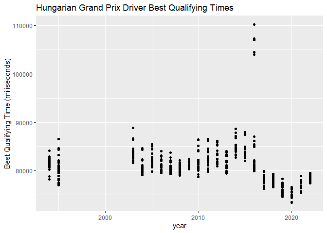

```r
ggplot(f1_circuit11) +
  geom_point(aes(x = year, y = bestQ)) +
  labs(title = "Hungarian Grand Prix Driver Best Qualifying Times",
       y = "Best Qualifying Time (miliseconds)")
```

2. Mean qualifying time for each year over year

Solution:

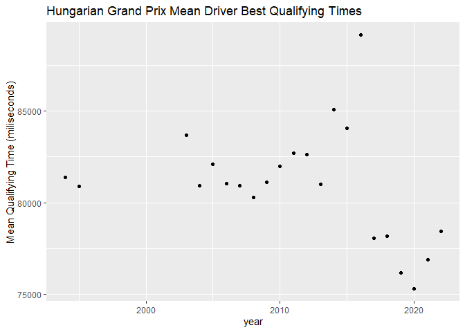

```r
ggplot(plot_df) +
  geom_point(aes(x = year, y = Mean))  +
  labs(title = "Hungarian Grand Prix Mean Driver Best Qualifying Times",
       y = "Mean Qualifying Time (miliseconds)")
```

3. Standard deviation for each year over year

Solution

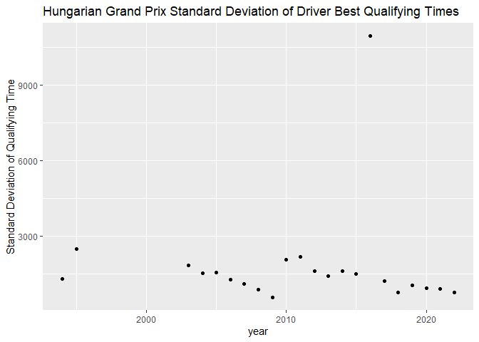

```r
ggplot(plot_df) +
  geom_point(aes(x = year, y = SD))  +
  labs(title = "Hungarian Grand Prix Standard Deviation of Driver Best Qualifying Times",
       y = "Standard Deviation of Qualifying Time")
```

4. Mean divided by standard deviation over year

Solution:

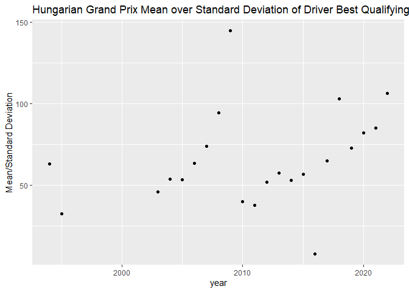

```r
ggplot(plot_df) +
  geom_point(aes(x = year, y = MSD))  +
  labs(title = "Hungarian Grand Prix Mean over Standard Deviation of Driver Best Qualifying Times",
       y = "Mean/Standard Deviation")
```